# Ich hole das Beste aus Ihrem Text.

Sie haben viel Zeit und Arbeit in Ihren Text gesteckt. Lassen Sie das die Welt sehen!

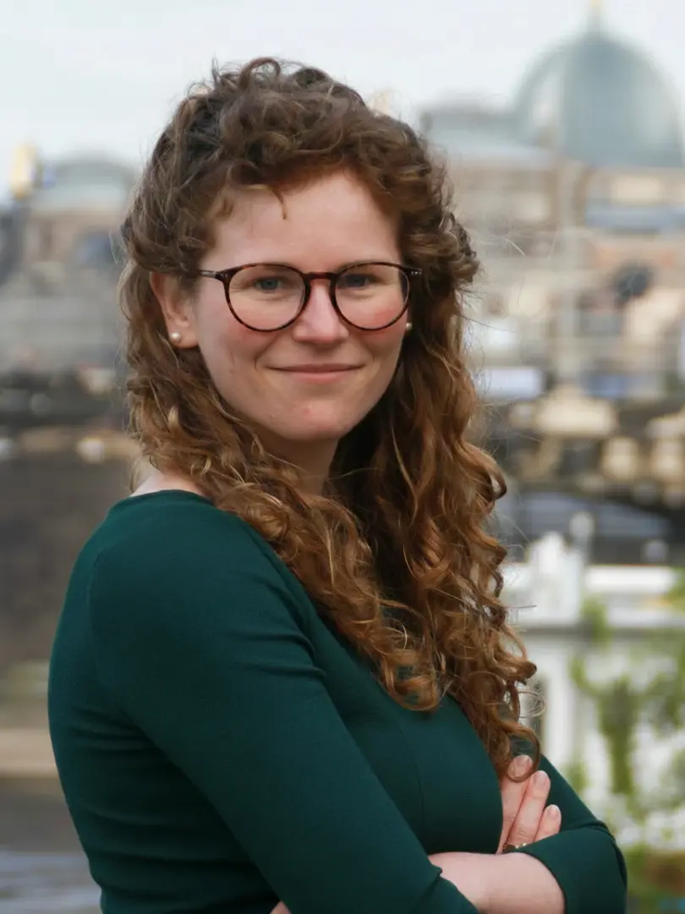

# Ein Lektorat macht Ihren Text runder.

Vielen Lesenden fällt es nicht direkt auf, wenn ein Komma fehlt, eine Schreibweise inkonsistent ist oder im Satz ein Füllwort steht. Aber unbewusst passt dann etwas nicht ganz.

Hier komme ich ins Spiel: Ich finde die Kleinigkeiten, über die Lesende stolpern. Ich passe sie an, und der Text wird runder.

# Mein Angebot

Im Lektorat passe ich Ihren Text an – wenn gewünscht, auch LaTeX-Texte in Overleaf. Dabei entspricht der angepasste Text immer den Regeln der deutschen Rechtschreibung. Zusätzlich kann ich Feedback zu Struktur und Logik geben. Dementsprechend biete ich folgende Module an.

### Alle Textsorten

Vorschläge im Text

### Basislektorat

0,012 € / Wort

- Anpassung von Rechtschreibung
- Anpassung von Grammatik
- Anpassung von Zeichensetzung
- Vereinheitlichung des Schreibstils

### Wissenschaftliche Texte

Rückmeldung über Kommentare

### Konsistenzcheck

+ 0,012 € / Wort

- Rückmeldung zu Logik und Argumentation
- Rückmeldung zu rotem Faden und Lesendenführung
- Überprüfung auf Vollständigkeit

Vorschläge im Text

### Gendercheck

+ 0,006 € / Wort

- Überprüfung von konsistentem Gendern
- Anpassung von inkonsistenten Formulierungen
- individuelle Wahl der Gendermethode, z. B. mit Doppelpunkt (:)

# Ablauf

Ich möchte, dass jeder Schritt im Lektoratsprozess verständlich ist. Deshalb finden Sie hier den Ablauf einer Bestellung.

1. Sie geben Bescheid, wie viele Worte das Dokument hat und welche Module gebucht werden sollen.
2. Ich erstelle ein individuelles Angebot.
3. Sie nehmen das Angebot an und senden mir das Dokument als Word-Dokument zu oder teilen ein Overleaf-Projekt.
4. Ich lektoriere das Dokument innerhalb der vereinbarten Zeit (meist unter einer Woche). Darin passe ich den Text mit Track-Changes an und setze Kommentare.
5. Ich sende das lektorierte Dokument zurück.
6. Nachdem ich das Dokument zurückgegeben habe, ist der vereinbarte Lohn fällig.

Ich arbeite sorgfältig und effizient, um sicherzustellen, dass Ihr Dokument schnell und in bester Qualität zurückkommt. Bei Fragen stehe ich gerne zur Verfügung.

# Sollen wir loslegen?

Schreiben Sie mir gerne, wenn Sie Fragen haben oder ein Angebot wünschen. Ich freue mich darauf, Sie kennenzulernen und das Beste aus Ihrem Text zu holen!

Schreiben Sie mir eine Mail!